# Exercice chap 5

Go back to chapter 5

- Import datasets

```python
import pandas as pd
import numpy as np
import time
import re
import seaborn as sns
import plotly.express as px

t = time.time()
table_1 = pd.read_csv('data/table_1.csv')
table_2 = pd.read_csv('data/table_2.csv')
cities = pd.read_csv('data/cities_loc.csv')
time.time() - t
```

```
2.387356758117676
```

- Remove articles with no pmid and no DOI, and all articles before 1975

```python
t = time.time()
table_1 = table_1.dropna(subset = ['pmid', 'doi'])
time.time() - t

t = time.time()
table_2 = table_2[table_2.year_pub > 1975].dropna(subset = ['pmid'])
time.time() - t
```

```
0.04082179069519043
```

- Merge the two datasets, pmid is unique for each paper

```python
t = time.time()
final_table = table_1.merge(table_2, how = 'left', on = 'pmid').dropna()
time.time() - t

final_table
```

|  | pmid | doi | title | source | language | pubtype | pubmodel | authors | year_pub | has_data | oa | cited |
| --- | --- | --- | --- | --- | --- | --- | --- | --- | --- | --- | --- | --- |
| 0 | 32837036.0 | 10.1007/s12291-020-00919-0 | The Pathophysiology, Diagnosis and Treatment o... | MED | eng | {"pubType": ["review-article", "Review", "Jour... | "Print-Electronic" | <AUTHOR> Das SK Subir Kumar Das<AFFILIATION>De... | 2020.0 | N | Y | 0.0 |
| 1 | 32196410.0 | 10.1080/22221751.2020.1746199 | Hypothesis for potential pathogenesis of SARS-... | MED | eng | {"pubType": ["review-article", "Journal Articl... | "Print" | <AUTHOR> Lin L Ling Lin<AFFILIATION>Department... | 2020.0 | N | Y | 61.0 |
| 2 | 32778421.0 | 10.1016/j.jiph.2020.07.011 | The outbreak of the novel severe acute respira... | MED | eng | {"pubType": ["review-article", "Review", "Jour... | "Print-Electronic" | <AUTHOR> Bchetnia M Mbarka Bchetnia<AFFILIATIO... | 2020.0 | N | Y | 0.0 |
| 3 | 32730205.0 | 10.1016/j.ijsu.2020.07.032 | A comparative overview of COVID-19, MERS and S... | MED | eng | {"pubType": ["review-article", "Review", "Jour... | "Print-Electronic" | <AUTHOR> Liu J Jie Liu<AFFILIATION>Department ... | 2020.0 | N | Y | 0.0 |
| 4 | 32394467.0 | 10.1002/jcp.29785 | A global treatments for coronaviruses includin... | MED | eng | {"pubType": ["review-article", "Review", "Jour... | "Print-Electronic" | <AUTHOR> Yousefi B Bahman Yousefi<AFFILIATION>... | 2020.0 | N | Y | 1.0 |
| ... | ... | ... | ... | ... | ... | ... | ... | ... | ... | ... | ... | ... |
| 108956 | 7704896.0 | 10.1128/cmr.8.1.87-112.1995 | Feline immunodeficiency virus: an interesting ... | MED | eng | {"pubType": ["Research Support, Non-U.S. Gov't... | "Print" | <AUTHOR> Bendinelli M M Bendinelli<AFFILIATION... | 1995.0 | N | N | 208.0 |
| 108967 | 22696127.0 | 10.1007/s13244-012-0153-4 | ECR 2012 Book of Abstracts - A - Postergraduat... | MED | eng | {"pubType": ["calendar", "Journal Article"]} | "Print" | <AUTHOR><AFFILIATION>None | 2012.0 | N | Y | 2.0 |
| 108969 | 3368329.0 | 10.1093/nar/16.suppl.r315 | Codon usage tabulated from the GenBank Genetic... | MED | eng | {"pubType": ["Comparative Study", "Research Su... | "Print" | <AUTHOR> Aota S S Aota<AFFILIATION>National In... | 1988.0 | N | N | 90.0 |
| 108970 | 25412402.0 | 10.1002/14651858.cd000011.pub4 | Interventions for enhancing medication adherence. | MED | eng | {"pubType": ["Meta-Analysis", "Research Suppor... | "Electronic" | <AUTHOR> Nieuwlaat R Robby Nieuwlaat<AFFILIATI... | 2014.0 | N | N | 222.0 |
| 108971 | 21994484.0 | 10.1007/s13225-011-0088-y | European species of Hypocrea part II: species ... | MED | eng | {"pubType": ["research-article", "Journal Arti... | "Print" | <AUTHOR> Jaklitsch WM Walter M Jaklitsch<AFFIL... | 2011.0 | Y | Y | 44.0 |

107103 rows × 12 columns

- Create a new variable with the number of authors for each paper

```python
t = time.time()
final_table = final_table.assign(nb_aut = final_table.authors.map(lambda aut: len(re.findall('<AUTHOR>',aut))))
time.time() - t
final_table[['pmid','nb_aut']]
```

|  | pmid | nb_aut |
| --- | --- | --- |
| 0 | 32837036.0 | 1 |
| 1 | 32196410.0 | 4 |
| 2 | 32778421.0 | 4 |
| 3 | 32730205.0 | 7 |
| 4 | 32394467.0 | 6 |
| ... | ... | ... |
| 108956 | 7704896.0 | 9 |
| 108967 | 22696127.0 | 1 |
| 108969 | 3368329.0 | 5 |
| 108970 | 25412402.0 | 16 |
| 108971 | 21994484.0 | 1 |

107103 rows × 2 columns

```python
t = time.time()
final_table = final_table[final_table.nb_aut > 0]
time.time() - t
```

```
0.024890422821044922
```

- plot distribution for the log(number of authors +1)

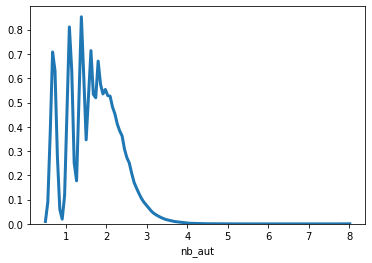

```python
sns.distplot(np.log(final_table.nb_aut +1), hist = False, kde = True,
                 kde_kws = {'linewidth': 3})
```

- How many papers contains 'deep learning' or 'machine learning' and 'neural network' (also with a 's' for neural networks) in their title ? Create a binary variable to save this information. What is the mean of authors for ML papers and non#ML papers ?
- Transform has_data and oa into binary variable also, what is the share of ML paper that are oa

```python
t = time.time()
final_table[['title']] = final_table.title.str.lower()
final_table = final_table.assign(
    ML = np.where(final_table.title.str.contains('deep learning|machine learning|neural networks?'),1,0),
    has_data = np.where(final_table.has_data == 'Y',1,0),
    oa = np.where(final_table.oa == 'Y',1,0))
time.time() - t

final_table
```

|  | pmid | doi | title | source | language | pubtype | pubmodel | authors | year_pub | has_data | oa | cited | nb_aut | ML |
| --- | --- | --- | --- | --- | --- | --- | --- | --- | --- | --- | --- | --- | --- | --- |
| 0 | 32837036.0 | 10.1007/s12291-020-00919-0 | the pathophysiology, diagnosis and treatment o... | MED | eng | {"pubType": ["review-article", "Review", "Jour... | "Print-Electronic" | <AUTHOR> Das SK Subir Kumar Das<AFFILIATION>De... | 2020.0 | 0 | 1 | 0.0 | 1 | 0 |
| 1 | 32196410.0 | 10.1080/22221751.2020.1746199 | hypothesis for potential pathogenesis of sars-... | MED | eng | {"pubType": ["review-article", "Journal Articl... | "Print" | <AUTHOR> Lin L Ling Lin<AFFILIATION>Department... | 2020.0 | 0 | 1 | 61.0 | 4 | 0 |
| 2 | 32778421.0 | 10.1016/j.jiph.2020.07.011 | the outbreak of the novel severe acute respira... | MED | eng | {"pubType": ["review-article", "Review", "Jour... | "Print-Electronic" | <AUTHOR> Bchetnia M Mbarka Bchetnia<AFFILIATIO... | 2020.0 | 0 | 1 | 0.0 | 4 | 0 |
| 3 | 32730205.0 | 10.1016/j.ijsu.2020.07.032 | a comparative overview of covid-19, mers and s... | MED | eng | {"pubType": ["review-article", "Review", "Jour... | "Print-Electronic" | <AUTHOR> Liu J Jie Liu<AFFILIATION>Department ... | 2020.0 | 0 | 1 | 0.0 | 7 | 0 |
| 4 | 32394467.0 | 10.1002/jcp.29785 | a global treatments for coronaviruses includin... | MED | eng | {"pubType": ["review-article", "Review", "Jour... | "Print-Electronic" | <AUTHOR> Yousefi B Bahman Yousefi<AFFILIATION>... | 2020.0 | 0 | 1 | 1.0 | 6 | 0 |
| ... | ... | ... | ... | ... | ... | ... | ... | ... | ... | ... | ... | ... | ... | ... |
| 108956 | 7704896.0 | 10.1128/cmr.8.1.87-112.1995 | feline immunodeficiency virus: an interesting ... | MED | eng | {"pubType": ["Research Support, Non-U.S. Gov't... | "Print" | <AUTHOR> Bendinelli M M Bendinelli<AFFILIATION... | 1995.0 | 0 | 0 | 208.0 | 9 | 0 |
| 108967 | 22696127.0 | 10.1007/s13244-012-0153-4 | ecr 2012 book of abstracts - a - postergraduat... | MED | eng | {"pubType": ["calendar", "Journal Article"]} | "Print" | <AUTHOR><AFFILIATION>None | 2012.0 | 0 | 1 | 2.0 | 1 | 0 |
| 108969 | 3368329.0 | 10.1093/nar/16.suppl.r315 | codon usage tabulated from the genbank genetic... | MED | eng | {"pubType": ["Comparative Study", "Research Su... | "Print" | <AUTHOR> Aota S S Aota<AFFILIATION>National In... | 1988.0 | 0 | 0 | 90.0 | 5 | 0 |
| 108970 | 25412402.0 | 10.1002/14651858.cd000011.pub4 | interventions for enhancing medication adherence. | MED | eng | {"pubType": ["Meta-Analysis", "Research Suppor... | "Electronic" | <AUTHOR> Nieuwlaat R Robby Nieuwlaat<AFFILIATI... | 2014.0 | 0 | 0 | 222.0 | 16 | 0 |
| 108971 | 21994484.0 | 10.1007/s13225-011-0088-y | european species of hypocrea part ii: species ... | MED | eng | {"pubType": ["research-article", "Journal Arti... | "Print" | <AUTHOR> Jaklitsch WM Walter M Jaklitsch<AFFIL... | 2011.0 | 1 | 1 | 44.0 | 1 | 0 |

107103 rows × 14 columns

```python
np.sum(final_table.ML)
np.sum(final_table.oa)
np.sum(final_table.has_data)

final_table.groupby('ML').agg({'nb_aut':np.mean,
                               'oa':np.mean})
```

| ML | nb_aut | oa |
| --- | --- | --- |
| 0 | 5.772364 | 0.726677 |
| 1 | 6.058559 | 0.801802 |

- Clean up pubtype, for simplicity just get the first type

```python
t = time.time()
final_table[['pub_type']] = final_table.pubtype.map(lambda pubtype: re.findall('\[\"(.*?)\"',pubtype)[0])
time.time() - t

final_table[['pubtype','pub_type']]
```

|  | pubtype | pub_type |
| --- | --- | --- |
| 0 | {"pubType": ["review-article", "Review", "Jour... | review-article |
| 1 | {"pubType": ["review-article", "Journal Articl... | review-article |
| 2 | {"pubType": ["review-article", "Review", "Jour... | review-article |
| 3 | {"pubType": ["review-article", "Review", "Jour... | review-article |
| 4 | {"pubType": ["review-article", "Review", "Jour... | review-article |
| ... | ... | ... |
| 108956 | {"pubType": ["Research Support, Non-U.S. Gov't... | Research Support, Non-U.S. Gov't |
| 108967 | {"pubType": ["calendar", "Journal Article"]} | calendar |
| 108969 | {"pubType": ["Comparative Study", "Research Su... | Comparative Study |
| 108970 | {"pubType": ["Meta-Analysis", "Research Suppor... | Meta-Analysis |
| 108971 | {"pubType": ["research-article", "Journal Arti... | research-article |

107103 rows × 2 columns

- What is the pub type with the highest mean/sd of citation ? (use cited and the cleaned pub_type)

```python
final_table.groupby('pub_type').agg({'cited':np.mean}).sort_values('cited',ascending = False)
final_table.groupby('pub_type').agg({'cited':lambda x : np.std(x,ddof = 1)}).sort_values('cited',ascending = False)
```

| pub_type | cited |
| --- | --- |
| Consensus Development Conference | 392.044048 |
| Research Support, N.I.H., Intramural | 144.450609 |
| Research Support, U.S. Gov't, P.H.S. | 97.102551 |
| editorial | 90.848164 |
| Clinical Conference | 84.303766 |
| ... | ... |
| Equivalence Trial | NaN |
| Personal Narratives | NaN |
| Twin Study | NaN |
| Validation Studies | NaN |
| obituary | NaN |

83 rows × 1 columns

- Which are the most representative country by year ? You may want to separate rows for each authors to get all countries involved in the paper, in an authors have multiple affiliations, take the first one. Store it in an other tibble, keep only pmid and authors, get the country for each author from the loc_cities.csv.

```python
countries = list(cities.country.str.lower().drop_duplicates())

countries_pd = final_table[['pmid', 'authors']]

t = time.time()
countries_pd = countries_pd.assign(
    authors=countries_pd.authors.str.split('<AUTHOR>')).explode('authors')
time.time() - t
countries_pd
```

|  | pmid | authors |
| --- | --- | --- |
| 0 | 32837036.0 |  |
| 0 | 32837036.0 | Das SK Subir Kumar Das<AFFILIATION>Department... |
| 1 | 32196410.0 |  |
| 1 | 32196410.0 | Lin L Ling Lin<AFFILIATION>Department of Infe... |
| 1 | 32196410.0 | Lu L Lianfeng Lu<AFFILIATION>Department of In... |
| ... | ... | ... |
| 108970 | 25412402.0 | Jedraszewski D Dawn Jedraszewski<AFFILIATION>... |
| 108970 | 25412402.0 | Cotoi C Chris Cotoi<AFFILIATION>None |
| 108970 | 25412402.0 | Haynes RB R Brian Haynes<AFFILIATION>None |
| 108971 | 21994484.0 |  |
| 108971 | 21994484.0 | Jaklitsch WM Walter M Jaklitsch<AFFILIATION>D... |

725404 rows × 2 columns

```python
t = time.time()
countries_pd = countries_pd[(countries_pd.authors != '')
                                & (-countries_pd.authors.str.contains('<AFFILIATION>None'))]
time.time() - t


t = time.time()
countries_pd = countries_pd.assign(
    authors = countries_pd.authors.map(lambda aff: aff.split('<AFFILIATION>')[1])).drop_duplicates()
time.time() - t

countries_pd
```

|  | pmid | authors |
| --- | --- | --- |
| 0 | 32837036.0 | Department of Biochemistry, College of Medicin... |
| 1 | 32196410.0 | Department of Infectious Diseases, Peking Unio... |
| 1 | 32196410.0 | Department of Infectious Diseases, Peking Unio... |
| 2 | 32778421.0 | Université du Québec à Chicoutimi (UQAC), Dépa... |
| 2 | 32778421.0 | Centre de recherche, Institut universitaire de... |
| ... | ... | ... |
| 108952 | 18843651.0 | Department of Anesthesiology, Pharmacology and... |
| 108956 | 7704896.0 | Department of Biomedicine, University of Pisa,... |
| 108969 | 3368329.0 | National Institute of Genetics, Mishima, Japan. |
| 108970 | 25412402.0 | Department of Clinical Epidemiology and Biosta... |
| 108971 | 21994484.0 | Department of Systematic and Evolutionary Bota... |

291655 rows × 2 columns

```python
t = time.time()
for abr, name in zip([' USA', ' UK', ' Korea'], ['United States', 'United Kingdom', 'South Korea']):
    countries_pd.authors = countries_pd.authors.map(lambda aff: re.sub(abr,name,aff))

countries_pd.authors = countries_pd.authors.str.lower()
time.time() - t
```

```
1.5909476280212402
```

```python
t = time.time()
countries_pd = countries_pd[countries_pd.authors.map(lambda aff: any([country in aff for country in countries]))]
countries_matched = countries_pd.authors.map(lambda aff: [country for country in countries if country in aff][0])
countries_pd = countries_pd.assign(country = countries_matched).drop('authors', axis = 1)
time.time() - t
```

```
24.330344200134277
```

```python
t = time.time()
countries_pd = countries_pd[countries_pd.country != ''].drop_duplicates()
time.time() - t
countries_pd

t = time.time()
countries_year = countries_pd.merge(final_table[['pmid','year_pub']], how = 'left', on = 'pmid')
time.time() - t
countries_year


countries_year = countries_year.groupby(['country', 'year_pub']).agg(n = ('pmid', len)).sort_values('n', ascending = False)
countries_year = countries_year.reset_index()
countries_year
```

|  | country | year_pub | n |
| --- | --- | --- | --- |
| 0 | united states | 2020.0 | 11668.0 |
| 1 | china | 2020.0 | 7888.0 |
| 2 | united kingdom | 2020.0 | 6262.0 |
| 3 | italy | 2020.0 | 5910.0 |
| 4 | india | 2020.0 | 3297.0 |
| ... | ... | ... | ... |
| 1904 | mexico | 2003.0 | 1.0 |
| 1905 | mexico | 2005.0 | 1.0 |
| 1906 | mexico | 2010.0 | 1.0 |
| 1907 | micronesia | 2014.0 | 1.0 |
| 1908 | lebanon | 2014.0 | 1.0 |

1909 rows × 3 columns

- Select the top 25 of countries involved in coronavirus research since 2001, plot the evolution on a bar chart with plot_ly

```python
wide_countries = countries_year.pivot(index="year_pub", columns="country", values="n").reset_index()
wide_countries = wide_countries[wide_countries.year_pub > 2000]

countries_to_plot = list(wide_countries.fillna(0).drop('year_pub',axis = 1).apply(sum).sort_values()[-25:].index)

fig = px.bar(wide_countries, x="year_pub", y=countries_to_plot)
fig.update_yaxes(type="log")
fig.show()
```

[interactive chart not shown]